# coiba_tool_data_analysis

Brendan Barrett

11/26/2020

# Intro

This is a prelimnary analysis of the Coiba Tool Dataset. You can access all the code and data on Github as this link https://github.com/bjbarrett/coibatooldata. You need permission to access this, as it is private, so let me know if you cannot.

First thing we will do is get some basic summary of the dimensions for stone tools.

```r
summary(d$width)
```

```
##    Min. 1st Qu.  Median    Mean 3rd Qu.    Max.
##   10.64   70.00   86.00   85.01  100.64  138.40
```

```r
summary(d$length)
```

```
##    Min. 1st Qu.  Median    Mean 3rd Qu.    Max.
##    61.0   103.0   121.0   120.8   138.0   197.0
```

```r
summary(d$thickness)
```

```
##    Min. 1st Qu.  Median    Mean 3rd Qu.    Max.
##   27.76   50.00   56.21   57.58   63.68   97.93
```

## Stone Tool Dimensions

```r
lm1 <- lm(length~width , data=d)
summary(lm1)
```

```
##
## Call:
## lm(formula = length ~ width, data = d)
##
## Residuals:
##     Min      1Q  Median      3Q     Max
## -39.443 -15.950  -2.063  12.145  64.415
##
## Coefficients:
##             Estimate Std. Error t value Pr(>|t|)
## (Intercept) 59.27712    7.47722   7.928 9.89e-13 ***
## width        0.72403    0.08532   8.486 4.76e-14 ***
## ---
## Signif. codes:  0 '***' 0.001 '**' 0.01 '*' 0.05 '.' 0.1 ' ' 1
##
## Residual standard error: 20.62 on 127 degrees of freedom
## Multiple R-squared:  0.3618, Adjusted R-squared:  0.3568
## F-statistic:    72 on 1 and 127 DF,  p-value: 4.764e-14
```

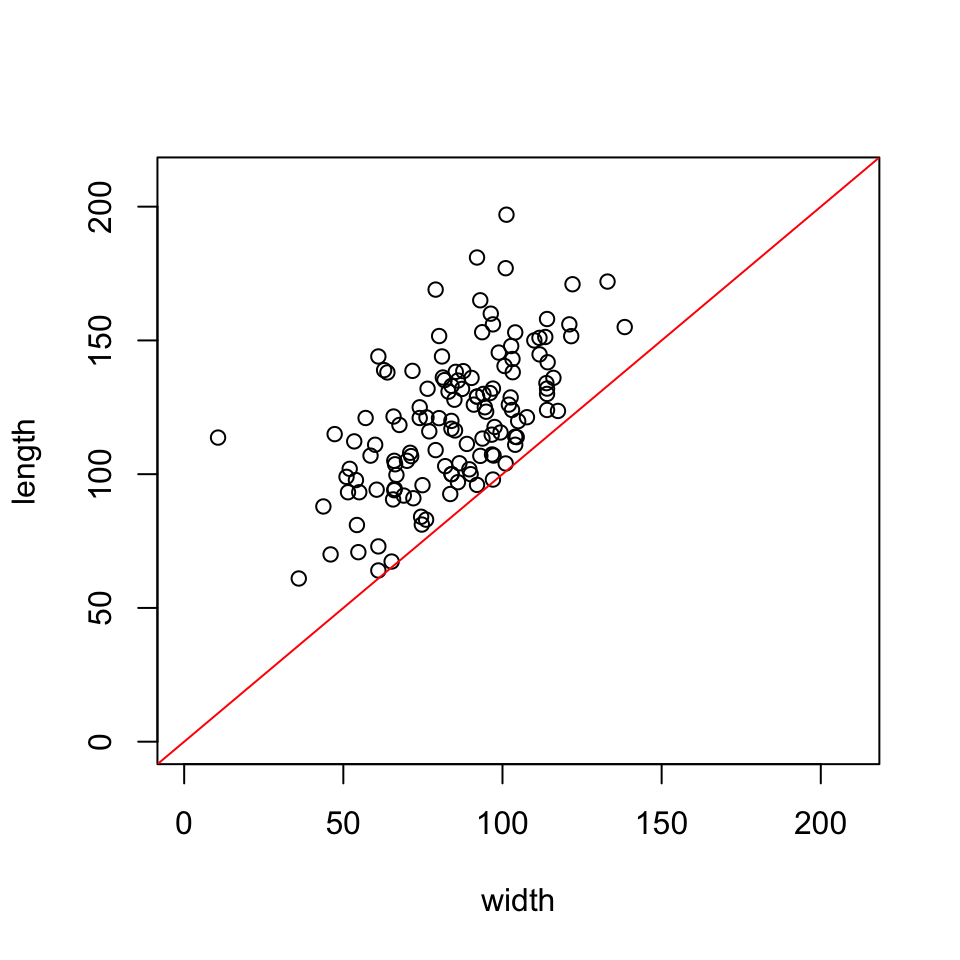

```r
plot(length~width , data=d , ylim=c(0,210) , xlim=c(0,210))
abline(a = 0, b = 1, col="red")
```

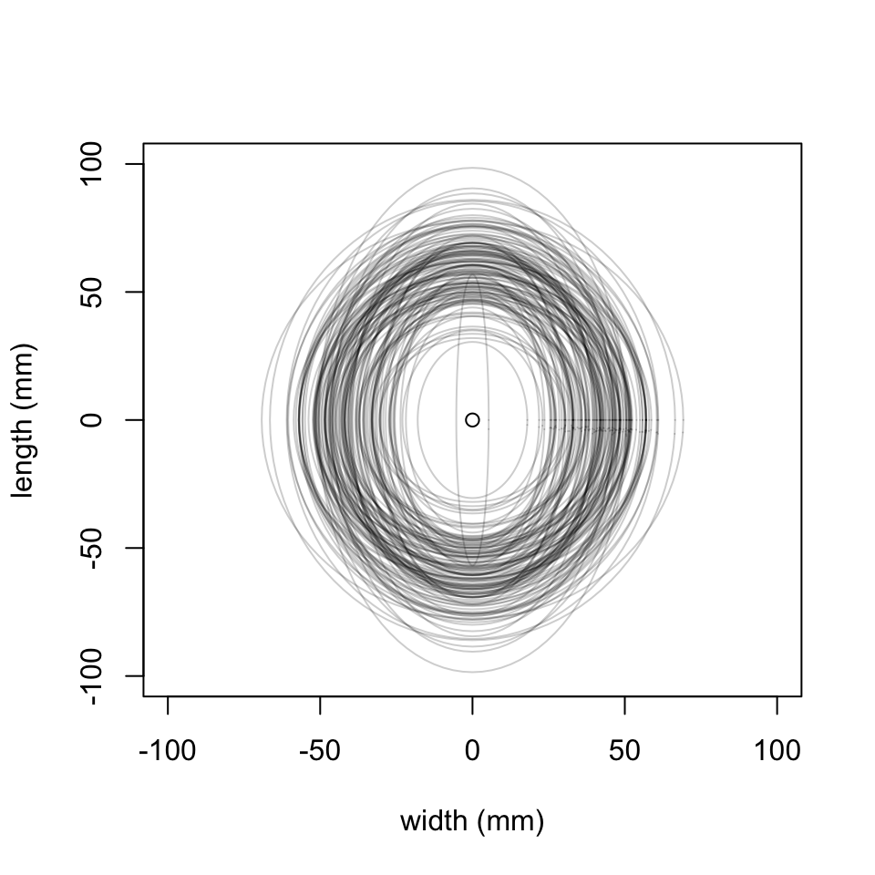

```r
plot(0,0 , xlim=c(-100,100) , ylim=c(-100,100) , xlab="width (mm)" , ylab="length (mm)" )
for (i in 1:nrow(d)){
  draw.ellipse(x=0 , y=0 , a = c(d$width[i])/2, b = c(d$length[i])[1]/2, angle = 0,
               nv = 100, border = col.alpha(1,0.2), col = NA, lty = 1, lwd = 1)
}
```

```
##
## Call:
## lm(formula = thickness ~ width, data = d)
##
## Residuals:
##     Min      1Q  Median      3Q     Max
## -24.971  -9.507  -1.311   6.644  38.342
##
## Coefficients:
##             Estimate Std. Error t value Pr(>|t|)
## (Intercept) 36.30266    4.68548   7.748 2.60e-12 ***
## width        0.25033    0.05347   4.682 7.19e-06 ***
## ---
## Signif. codes:  0 '***' 0.001 '**' 0.01 '*' 0.05 '.' 0.1 ' ' 1
##
## Residual standard error: 12.92 on 127 degrees of freedom
## Multiple R-squared:  0.1472, Adjusted R-squared:  0.1405
## F-statistic: 21.92 on 1 and 127 DF,  p-value: 7.188e-06
```

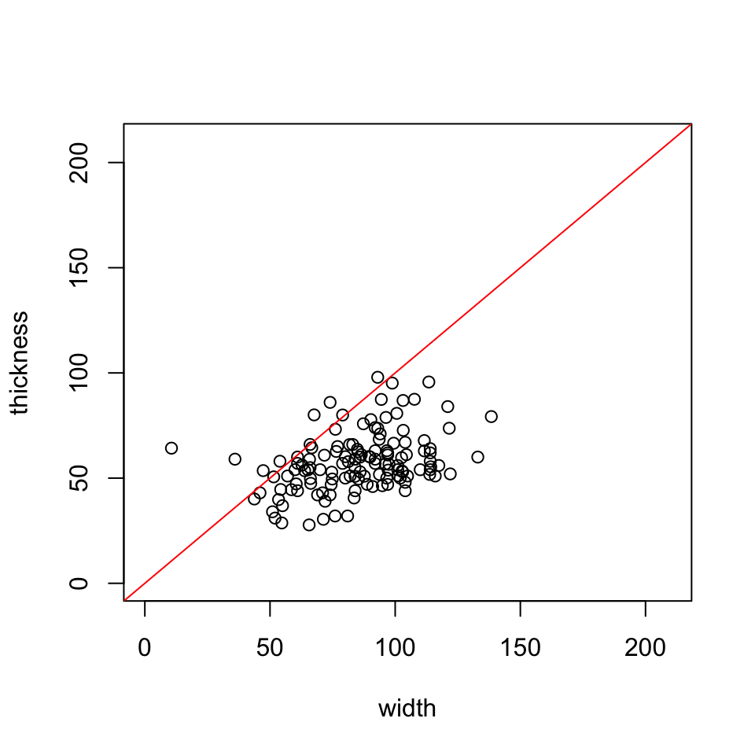

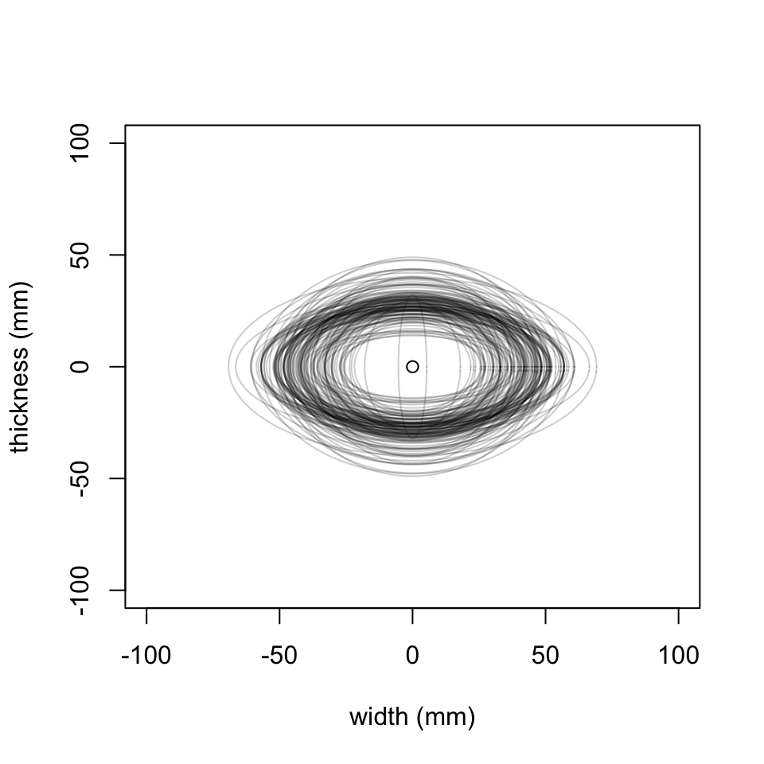

While length does scale with thickness, this seems to be more constrained.

```
##
## Call:
## lm(formula = thickness ~ length, data = d)
##
## Residuals:
##     Min      1Q  Median      3Q     Max
## -31.735  -7.930  -0.974   7.763  31.038
##
## Coefficients:
##             Estimate Std. Error t value Pr(>|t|)
## (Intercept) 25.50713    5.17985   4.924 2.58e-06 ***
## length       0.26547    0.04194   6.330 3.86e-09 ***
## ---
## Signif. codes:  0 '***' 0.001 '**' 0.01 '*' 0.05 '.' 0.1 ' ' 1
##
## Residual standard error: 12.2 on 127 degrees of freedom
## Multiple R-squared:  0.2398, Adjusted R-squared:  0.2338
## F-statistic: 40.07 on 1 and 127 DF,  p-value: 3.862e-09
```

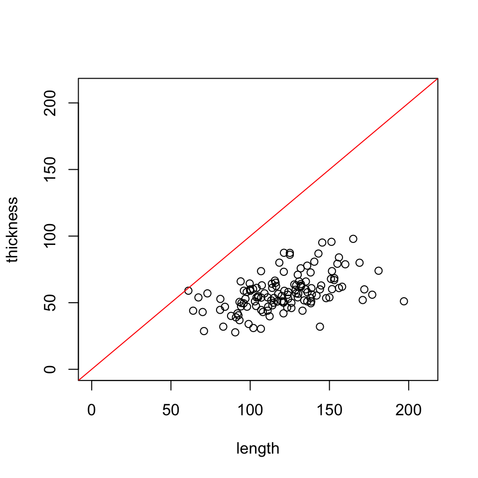

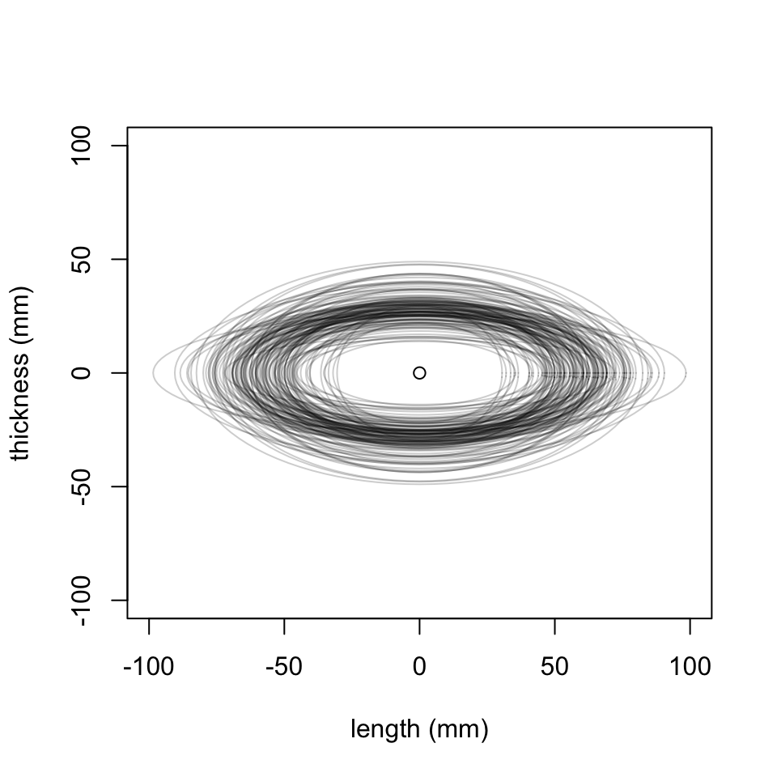

## Resource differences in mass

Here we can start to examine mass differences of stone tools, as it relates to resource being processed. One challenge of this data is that often we find hammers with multiple resources underneath them. We can account for this by using an interaction effect. I fit this model with STAN using Richard’s map2stan package. Outcome is a gamma distribution with an log-link function.

```
## Computing WAIC
```

```r
precis(m2)
```

```
##             mean        sd       5.5%        94.5%    n_eff     Rhat4
## a      6.6718644 0.0971746  6.5090776   6.81770733 287.3988 0.9998858
## bA    -0.1031800 0.1095821 -0.2723006   0.08148115 278.6686 0.9991944
## bS    -0.6863349 0.1197793 -0.8709176  -0.48611815 276.4505 0.9997542
## bAS    0.5868773 0.1448231  0.3490455   0.81432047 287.1202 0.9990005
## scale 98.5822146 7.3289662 87.6362049 110.80476745 518.1840 1.0006217
```

These interactions are hard to interpret but it is easier to visualize model predictions below. From parametr estimates it is clear that snails use smaller hammerstones to open. We reliably see that tools used to open shells (in this case hermit crabs and-less likely- snails) are far smaller than those used to open almendras and other resources.

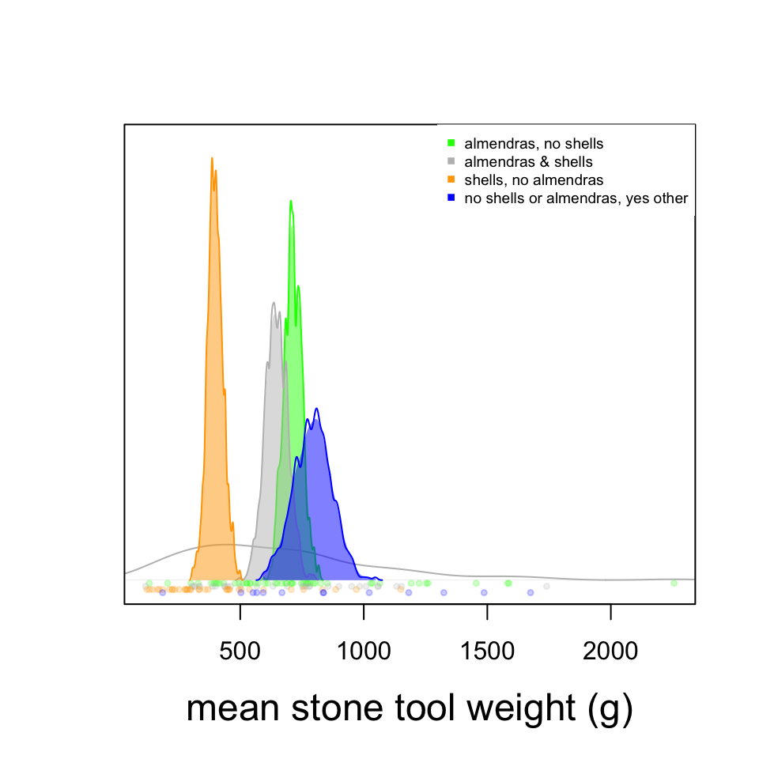